# Global Female Education Trends

Ryan Fuller

2022-12-27

This project will explore how the educational opportunities for girls have changed throughout the world since 1970. The dataset to be explored comes from the [World Bank’s Gender Data Portal](https://genderdata.worldbank.org/). The dataset includes indicators from fields including assets, education, employment, health, technology, violence, and more. This project will examine how primary, secondary and tertiary school enrollment has changed over time in different regions of the world as well as what countries have seen the most growth in expected years of schooling for girls.

The World Bank Gender Portal data frame consists of 262615 rows and 67 columns.

Here is a sample of the data frame:

| Country.Name | Country.Code | Indicator.Name | Indicator.Code | X1960 | X1961 |
| --- | --- | --- | --- | --- | --- |
| Africa Eastern and Southern | AFE | A woman can apply for a passport in the same way as a man (1=yes; 0=no) | SG.APL.PSPT.EQ | NA | NA |
| Africa Eastern and Southern | AFE | A woman can be head of household in the same way as a man (1=yes; 0=no) | SG.HLD.HEAD.EQ | NA | NA |
| Africa Eastern and Southern | AFE | A woman can choose where to live in the same way as a man (1=yes; 0=no) | SG.LOC.LIVE.EQ | NA | NA |
| Africa Eastern and Southern | AFE | A woman can get a job in the same way as a man (1=yes; 0=no) | SG.GET.JOBS.EQ | NA | NA |
| Africa Eastern and Southern | AFE | A woman can obtain a judgment of divorce in the same way as a man (1=yes; 0=no) | SG.OBT.DVRC.EQ | NA | NA |
| Africa Eastern and Southern | AFE | A woman can open a bank account in the same way as a man (1=yes; 0=no) | SG.OPN.BANK.EQ | NA | NA |

### Indicators

There are 991 indicators in the data frame. Here are some of them:

| Indicator.Name |
| --- |
| A woman can apply for a passport in the same way as a man (1=yes; 0=no) |
| A woman can be head of household in the same way as a man (1=yes; 0=no) |
| A woman can choose where to live in the same way as a man (1=yes; 0=no) |
| A woman can get a job in the same way as a man (1=yes; 0=no) |
| A woman can obtain a judgment of divorce in the same way as a man (1=yes; 0=no) |
| A woman can open a bank account in the same way as a man (1=yes; 0=no) |

### School Indicators

We want to focus on the indicators related to schooling, so we will identify indicators that contain the word “school” or “School”. Here are the school indicators in the data frame:

| Indicator.Name |
| --- |
| Adjusted net enrollment rate, primary (% of primary school age children) |
| Adjusted net enrollment rate, primary, female (% of primary school age children) |
| Adjusted net enrollment rate, primary, male (% of primary school age children) |
| Borrowed for education or school fees (% age 15+) |
| Borrowed for education or school fees, female (% age 15+) |
| Borrowed for education or school fees, male (% age 15+) |
| Children out of school (% of primary school age) |
| Children out of school, primary |
| Children out of school, primary, female |
| Children out of school, primary, male |
| Expected Years of School |
| Expected Years of School, Female |
| Expected Years of School, Male |
| Expected years of schooling |
| Expected years of schooling, female |
| Expected years of schooling, male |
| Female primary school age children out-of-school (%) |
| Learning poverty: Share of Children at the End-of-Primary age below minimum reading proficiency adjusted by Out-of-School Children (%) |
| Learning poverty: Share of Female Children at the End-of-Primary age below minimum reading proficiency adjusted by Out-of-School Children (%) |
| Learning poverty: Share of Male Children at the End-of-Primary age below minimum reading proficiency adjusted by Out-of-School Children (%) |
| Learning-Adjusted Years of School |
| Learning-Adjusted Years of School, Female |
| Learning-Adjusted Years of School, Male |
| Male primary school age children out-of-school (%) |
| Net intake rate in grade 1 (% of official school-age population) |
| Net intake rate in grade 1, female (% of official school-age population) |
| Net intake rate in grade 1, male (% of official school-age population) |
| Paid school fees in the past year (% age 15+) |
| Paid school fees in the past year, female (% age 15+) |
| Paid school fees in the past year, male (% age 15+) |
| Progression to secondary school (%) |
| Progression to secondary school, female (%) |
| Progression to secondary school, male (%) |
| Rate of out-of-school youth of upper secondary school age, female (%) |
| Rate of out-of-school youth of upper secondary school age, male (%) |
| Saved for education or school fees (% age 15+) |
| Saved for education or school fees, female (% age 15+) |
| Saved for education or school fees, male (% age 15+) |
| School enrollment, preprimary (% gross) |
| School enrollment, preprimary, female (% gross) |
| School enrollment, preprimary, male (% gross) |
| School enrollment, primary (% gross) |
| School enrollment, primary (% net) |
| School enrollment, primary (gross), gender parity index (GPI) |
| School enrollment, primary and secondary (gross), gender parity index (GPI) |
| School enrollment, primary, female (% gross) |
| School enrollment, primary, female (% net) |
| School enrollment, primary, male (% gross) |
| School enrollment, primary, male (% net) |
| School enrollment, secondary (% gross) |
| School enrollment, secondary (% net) |
| School enrollment, secondary (gross), gender parity index (GPI) |
| School enrollment, secondary, female (% gross) |
| School enrollment, secondary, female (% net) |
| School enrollment, secondary, male (% gross) |
| School enrollment, secondary, male (% net) |
| School enrollment, tertiary (% gross) |
| School enrollment, tertiary (gross), gender parity index (GPI) |
| School enrollment, tertiary, female (% gross) |
| School enrollment, tertiary, male (% gross) |

### Indicators With Data

In Latin America, there is no school indicator data before 1970. Many school indicators do not have any data in Latin America or do not have data until the 80’s or 90’s. We will focus our study on school indicators that had data starting in 1970. Here are the school indicators with entries going back to 1970 in Latin America:

| Indicator.Name |
| --- |
| Children out of school (% of primary school age) |
| Children out of school, primary |
| Children out of school, primary, female |
| Children out of school, primary, male |
| Expected years of schooling |
| Expected years of schooling, female |
| Expected years of schooling, male |
| Progression to secondary school (%) |
| Progression to secondary school, female (%) |
| Progression to secondary school, male (%) |
| School enrollment, preprimary (% gross) |
| School enrollment, preprimary, female (% gross) |
| School enrollment, preprimary, male (% gross) |
| School enrollment, primary (% gross) |
| School enrollment, primary (% net) |
| School enrollment, primary (gross), gender parity index (GPI) |
| School enrollment, primary and secondary (gross), gender parity index (GPI) |
| School enrollment, primary, female (% gross) |
| School enrollment, primary, female (% net) |
| School enrollment, primary, male (% gross) |
| School enrollment, primary, male (% net) |
| School enrollment, secondary (% gross) |
| School enrollment, secondary (gross), gender parity index (GPI) |
| School enrollment, secondary, female (% gross) |
| School enrollment, secondary, male (% gross) |
| School enrollment, tertiary (% gross) |
| School enrollment, tertiary (gross), gender parity index (GPI) |
| School enrollment, tertiary, female (% gross) |
| School enrollment, tertiary, male (% gross) |

### Regions and Countries

There are 265 regions in the data frame. 217 are individual countries while others are continents or regions grouped by income. Here are some of the regions:

| Country.Name |
| --- |
| Africa Eastern and Southern |
| Africa Western and Central |
| Arab World |
| Caribbean small states |
| Central Europe and the Baltics |
| Early-demographic dividend |
| East Asia & Pacific |
| East Asia & Pacific (excluding high income) |
| East Asia & Pacific (IDA & IBRD) |
| Euro area |

We will start by analyzing the following regions to get a sense of female schooling trends across the world:

| North America |
| --- |
| Latin America & Caribbean |
| European Union |
| East Asia & Pacific |
| Middle East & North Africa |
| Sub-Saharan Africa |

### Expected Years of Schooling

We will start by examining how the [expected years of schooling](https://databank.worldbank.org/metadataglossary/world-development-indicators/series/SE.SCH.LIFE) have changed for males and females in different regions. Here is how this indicator is calculated:

*Expected years of schooling is the number of years a child of school entrance age is expected to spend at school, or university, including years spent on repetition. It is the sum of the age-specific enrollment ratios for primary, secondary, post-secondary non-tertiary and tertiary education.*

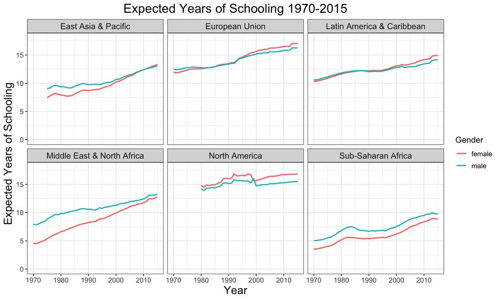

Expected years of schooling has increased from 1970 to 2015 in all regions. In almost all regions, the expected schooling for girls has approached or exceeded that of boys. The expected years of schooling in Middle East/North Africa in 2015 is about the same as it was for Europe in the 1970’s (about 13 years).

### School Enrollment Changes

We will now look at how primary, secondary, and tertiary school enrollment has changed for males and females in different regions. Note that there will be some instances where gross enrollment is over 100%. This is due to the way [gross enrollment](https://datahelpdesk.worldbank.org/knowledgebase/articles/114955-how-can-gross-school-enrollment-ratios-be-over-100) is calculated:

*“Gross” enrollment includes students of all ages. In other words, it includes students whose age exceeds the official age group (e.g. repeaters). Thus, if there is late enrollment, early enrollment, or repetition, the total enrollment can exceed the population of the age group that officially corresponds to the level of education – leading to ratios greater than 100 percent*

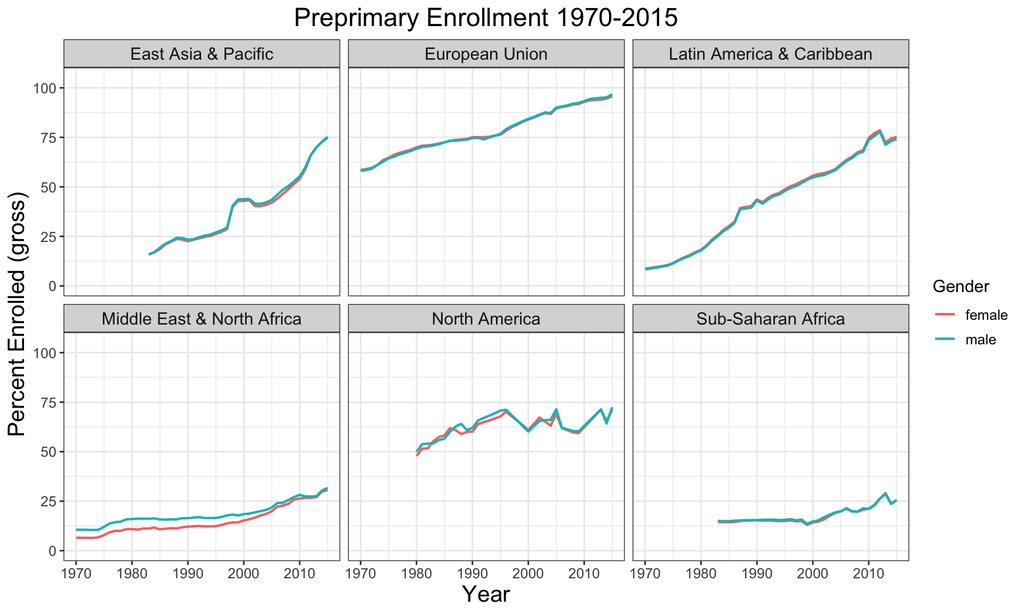

Preprimary enrollment is similar for girls and boys in each region and has increased the most in the Latin America/Caribbean and East Asia/Pacific regions. In Middle East/North Africa and Sub-Saharan Africa, enrollment has moderately increased since 1970, but is still under 40%, well below the other regions.

We will now look at net primary enrollment for males and females. As explained [here](https://databank.worldbank.org/metadataglossary/world-development-indicators/series/SE.PRM.NENR):

*net enrollment rate excludes overage and underage students and more accurately captures the system’s coverage and internal efficiency*

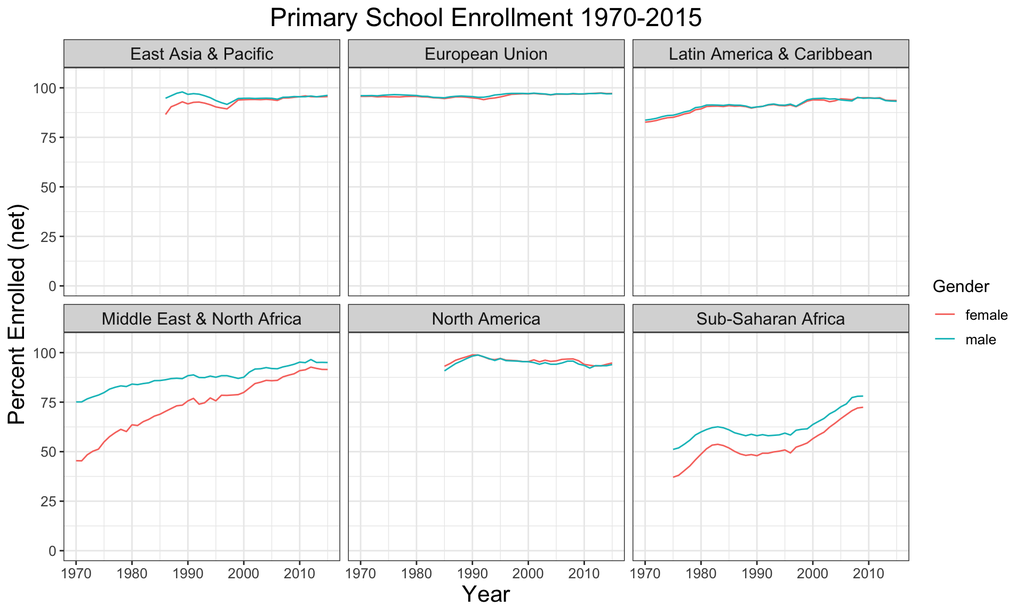

In 2015 net primary enrollment is at least 90% in all regions except Sub-Saharan Africa for which there has not been net primary enrollment data since 2009. The female net primary enrollment rate roughly doubled in the Middle East/North Africa and Sub-Saharan Africa regions in the years plotted above.

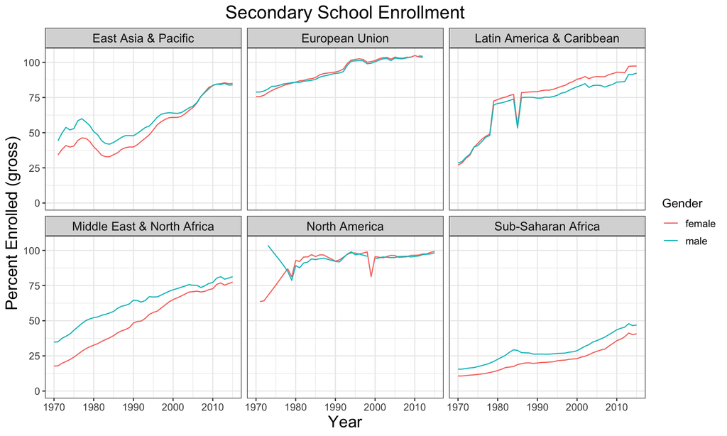

For secondary enrollment, the graphs still show a general increasing trend for boys and girls, but some regions experienced periods of enrollment declines. Secondary enrollment in the East Asia/Pacific region experienced a decline in the early 1980’s. Interestingly, in North America in the 1970’s, male enrollment sharply decreased while female enrollment sharply increased. It’s possible that conflicts that some countries in these regions were involved with caused these decreases.

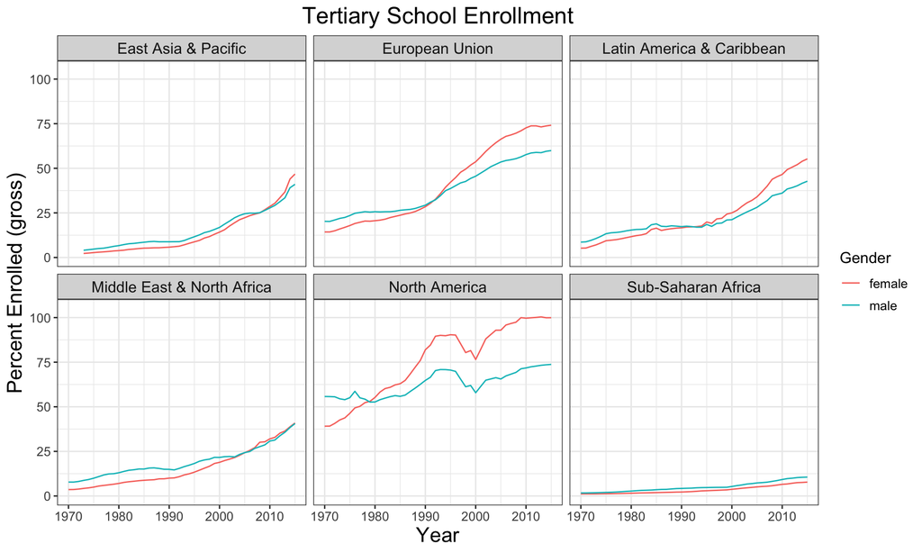

In all regions except Sub-Saharan Africa, female tertiary enrollment numbers exceeded that of males at some point. In the Latin America/Caribbean, North America, and the European Union, the gap is largest and appears to be widening. This could be due to the changing nature of work in these regions. In North America, the gross tertiary enrollment for females exceeds 100%, which indicates that many North American women are going back to school as adults.

### Gender Parity Index

We will now look at the Gender Parity Index (GPI) for different indicators. The GPI for gross enrollment is the ratio of girls to boys enrolled in public and private schools. A GPI of 0.5 indicates that there are half as many girls as boys enrolled. A ratio greater than 1.0 indicates that there are more girls than boys enrolled. We will start by looking at the [GPI for primary and secondary education enrollment](https://databank.worldbank.org/metadataglossary/gender-statistics/series/SE.ENR.PRSC.FM.ZS):

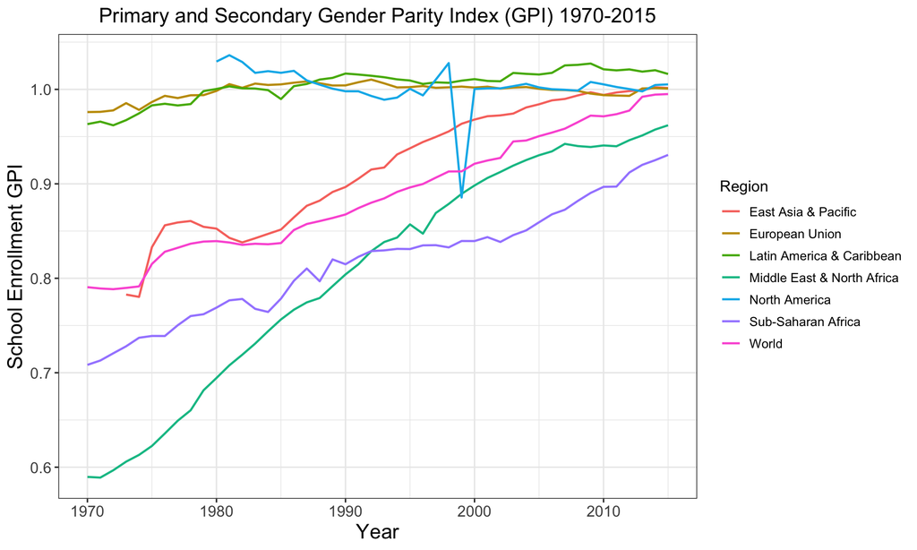

Since 1970, the primary and secondary enrollment GPI has steadily increased in all regions where it wasn’t already near 1.0 in 1970. There was a large, temporary drop in the North American GPI in the late 1990’s.

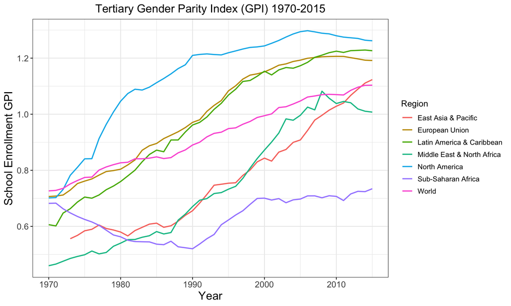

The tertiary enrollment GPI increased in all regions and, as of 2015, is larger than 1.0 in all regions except Sub-Saharan Africa. This means that in almost all regions of the world, there are more women than men pursuing post-secondary education.

### Indicator Distributions

We will now look at histograms for different indicators for a data frame that includes all 217 countries in the World Bank Gender Portal. Looking at histograms can help us identify global trends. Each histogram will include two sets of bins: one set from 1990 and one set from 2015. We will start by examining the distribution of female secondary school access in 1990 and in 2015.

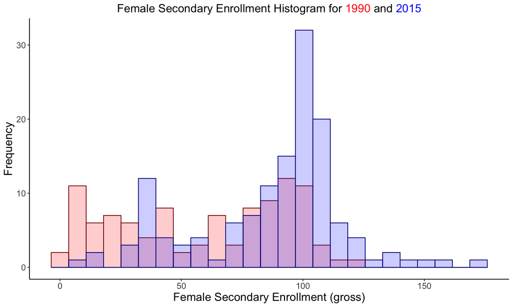

In 1990, female secondary enrollment percentages were fairly evenly distributed between 0% and 100%. In 2015, many more countries had gross enrollment figures near 100%.

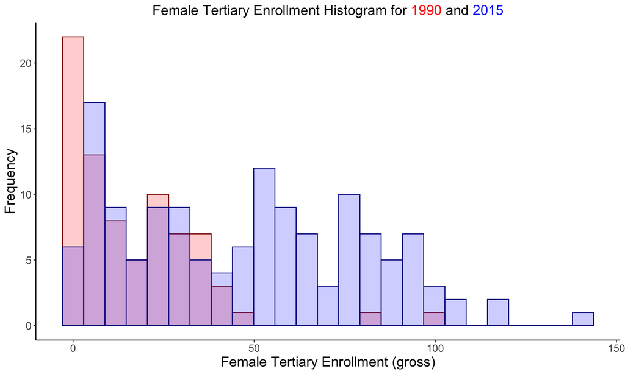

In 1990, female tertiary enrollment percentages were right skewed and almost entirely below 50%. In 2015, the distribution was more evenly distributed between 0% and 100%.

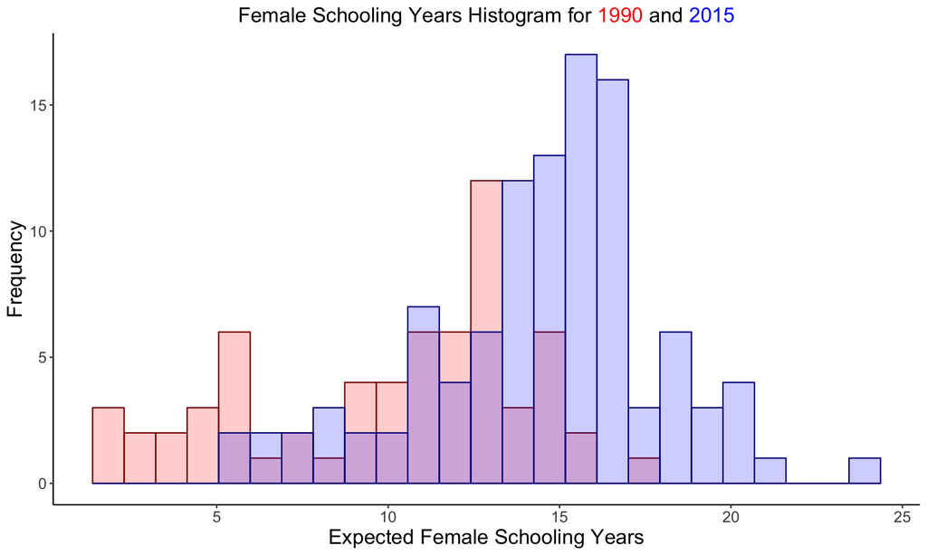

In 1990, the female schooling years were fairly evenly distributed between 0 and 15 years with a spike at 13. In 2015, the distribution is much closer to a normal distribution centered at 16 years.

### Countries With Highest Growth

We will now identify which countries have seen the most growth in expected years of schooling for girls. The graphs below will include data for the entire world as reference. Here are the countries where expected years of schooling for females grew the most from 1971 to 2015:

| Country.Name | growth_1971 |
| --- | --- |
| Turkey | 11.225589 |
| Iran, Islamic Rep. | 10.225600 |
| Burundi | 10.054390 |
| Benin | 9.943750 |
| Iceland | 9.278999 |
| Belgium | 8.804010 |

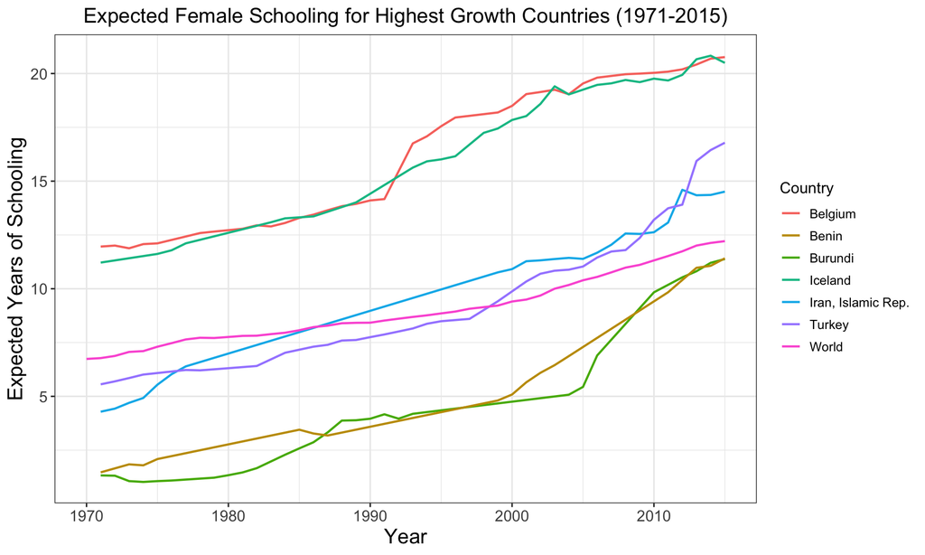

The six countries that had the largest growth in expected years of female schooling from 1970-2015 came from regions around the world: Europe (Belgium, Iceland), West Africa (Benin), East Africa (Burundi), the Middle East (Turkey, Iran). It is interesting that in 2015, girls in Benin and Burundi have the same expected schooling years as girls in Belgium and Iceland did in 1971 (about 12 years).

We will now look at countries that had the largest growth in expected years of female schooling in the 21st century. Here are the countries where expected schooling years for girls grew the most from 2000 to 2015:

| Country.Name | growth_2000 |
| --- | --- |
| Benin | 6.326730 |
| Nepal | 5.415940 |
| India | 5.035860 |
| Albania | 4.982810 |
| Mozambique | 4.299820 |
| Ghana | 4.097731 |

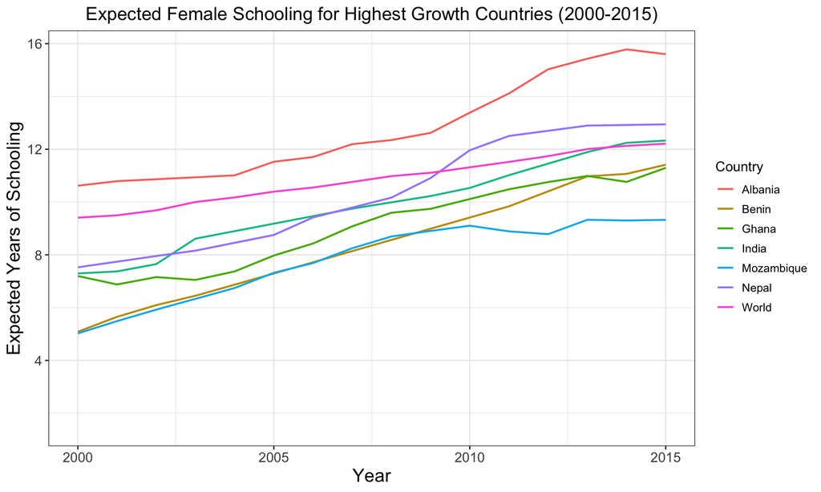

Africa and South Asia were most strongly represented in countries that experienced the largest growth in expected years of female schooling from 2000-2015.

### Conclusion

The data explored in this project tell a story of girls across the world enrolling in all levels of school at increasing rates. The Middle East, North Africa, and Sub-Saharan Africa have lower enrollment rates than the rest of the world, especially at the preprimary and tertiary levels. The expected years of schooling in these regions, however, are increasing and in some cases are approaching the enrollment rates and expected schooling years that countries in Europe had in 1970.

### Future Work

The countries that saw the highest growth in expected years of female schooling could be studied to see if policies they enacted could be adopted by other countries.

The gap between men and women with regards to tertiary enrollment in Europe and the Americas is worth exploring. Two questions that come to mind are:

- What is the reason that fewer men than women are pursuing post-secondary education?
- Is it a problem that fewer men than women are pursuing post-secondary education?

Another are for exploration is the connection between education and other fields such as violence, health, and employment.

- Is there a connection between female expected years of schooling and female property ownership?
- Is there a connection between female tertiary enrollment rates and violence experienced by women?